# 1. 补充、拆解并执行前12行代码

```python
# 导入pandas库，用于数据处理
import pandas as pd
# 导入train_test_split函数，用于将数据集划分为训练集和测试集
from sklearn.model_selection import train_test_split
# 导入KNN分类器
from sklearn.neighbors import KNeighborsClassifier as KNN
```

```python
# 加载数据集
df = pd.read_excel('手写体数字.xlsx')
df
```

|  | 对应数字 | 0 | 1 | 2 | 3 | 4 | 5 | 6 | 7 | 8 | ... | 1014 | 1015 | 1016 | 1017 | 1018 | 1019 | 1020 | 1021 | 1022 | 1023 |
| --- | --- | --- | --- | --- | --- | --- | --- | --- | --- | --- | --- | --- | --- | --- | --- | --- | --- | --- | --- | --- | --- |
| 0 | 0 | 0 | 0 | 0 | 0 | 0 | 0 | 0 | 0 | 0 | ... | 0 | 0 | 0 | 0 | 0 | 0 | 0 | 0 | 0 | 0 |
| 1 | 0 | 0 | 0 | 0 | 0 | 0 | 0 | 0 | 0 | 0 | ... | 0 | 0 | 0 | 0 | 0 | 0 | 0 | 0 | 0 | 0 |
| 2 | 0 | 0 | 0 | 0 | 0 | 0 | 0 | 0 | 0 | 0 | ... | 0 | 0 | 0 | 0 | 0 | 0 | 0 | 0 | 0 | 0 |
| 3 | 0 | 0 | 0 | 0 | 0 | 0 | 0 | 0 | 0 | 0 | ... | 0 | 0 | 0 | 0 | 0 | 0 | 0 | 0 | 0 | 0 |
| 4 | 0 | 0 | 0 | 0 | 0 | 0 | 0 | 0 | 0 | 0 | ... | 0 | 0 | 0 | 0 | 0 | 0 | 0 | 0 | 0 | 0 |
| ... | ... | ... | ... | ... | ... | ... | ... | ... | ... | ... | ... | ... | ... | ... | ... | ... | ... | ... | ... | ... | ... |
| 1929 | 9 | 0 | 0 | 0 | 0 | 0 | 0 | 0 | 0 | 0 | ... | 0 | 0 | 0 | 0 | 0 | 0 | 0 | 0 | 0 | 0 |
| 1930 | 9 | 0 | 0 | 0 | 0 | 0 | 0 | 0 | 0 | 0 | ... | 0 | 0 | 0 | 0 | 0 | 0 | 0 | 0 | 0 | 0 |
| 1931 | 9 | 0 | 0 | 0 | 0 | 0 | 0 | 0 | 0 | 0 | ... | 0 | 0 | 0 | 0 | 0 | 0 | 0 | 0 | 0 | 0 |
| 1932 | 9 | 0 | 0 | 0 | 0 | 0 | 0 | 0 | 0 | 0 | ... | 0 | 0 | 0 | 0 | 0 | 0 | 0 | 0 | 0 | 0 |
| 1933 | 9 | 0 | 0 | 0 | 0 | 0 | 0 | 0 | 0 | 0 | ... | 1 | 1 | 0 | 0 | 0 | 0 | 0 | 0 | 0 | 0 |

1934 rows × 1025 columns

```python
# 数据集中的第一列是目标变量，将其余列作为特征
X = df.drop('对应数字', axis=1)  # 特征
X
```

|  | 0 | 1 | 2 | 3 | 4 | 5 | 6 | 7 | 8 | 9 | ... | 1014 | 1015 | 1016 | 1017 | 1018 | 1019 | 1020 | 1021 | 1022 | 1023 |
| --- | --- | --- | --- | --- | --- | --- | --- | --- | --- | --- | --- | --- | --- | --- | --- | --- | --- | --- | --- | --- | --- |
| 0 | 0 | 0 | 0 | 0 | 0 | 0 | 0 | 0 | 0 | 0 | ... | 0 | 0 | 0 | 0 | 0 | 0 | 0 | 0 | 0 | 0 |
| 1 | 0 | 0 | 0 | 0 | 0 | 0 | 0 | 0 | 0 | 0 | ... | 0 | 0 | 0 | 0 | 0 | 0 | 0 | 0 | 0 | 0 |
| 2 | 0 | 0 | 0 | 0 | 0 | 0 | 0 | 0 | 0 | 0 | ... | 0 | 0 | 0 | 0 | 0 | 0 | 0 | 0 | 0 | 0 |
| 3 | 0 | 0 | 0 | 0 | 0 | 0 | 0 | 0 | 0 | 0 | ... | 0 | 0 | 0 | 0 | 0 | 0 | 0 | 0 | 0 | 0 |
| 4 | 0 | 0 | 0 | 0 | 0 | 0 | 0 | 0 | 0 | 0 | ... | 0 | 0 | 0 | 0 | 0 | 0 | 0 | 0 | 0 | 0 |
| ... | ... | ... | ... | ... | ... | ... | ... | ... | ... | ... | ... | ... | ... | ... | ... | ... | ... | ... | ... | ... | ... |
| 1929 | 0 | 0 | 0 | 0 | 0 | 0 | 0 | 0 | 0 | 0 | ... | 0 | 0 | 0 | 0 | 0 | 0 | 0 | 0 | 0 | 0 |
| 1930 | 0 | 0 | 0 | 0 | 0 | 0 | 0 | 0 | 0 | 0 | ... | 0 | 0 | 0 | 0 | 0 | 0 | 0 | 0 | 0 | 0 |
| 1931 | 0 | 0 | 0 | 0 | 0 | 0 | 0 | 0 | 0 | 0 | ... | 0 | 0 | 0 | 0 | 0 | 0 | 0 | 0 | 0 | 0 |
| 1932 | 0 | 0 | 0 | 0 | 0 | 0 | 0 | 0 | 0 | 0 | ... | 0 | 0 | 0 | 0 | 0 | 0 | 0 | 0 | 0 | 0 |
| 1933 | 0 | 0 | 0 | 0 | 0 | 0 | 0 | 0 | 0 | 0 | ... | 1 | 1 | 0 | 0 | 0 | 0 | 0 | 0 | 0 | 0 |

1934 rows × 1024 columns

```python
y = df['对应数字']  # 目标变量
y
```

```
0       0
1       0
2       0
3       0
4       0
       ..
1929    9
1930    9
1931    9
1932    9
1933    9
Name: 对应数字, Length: 1934, dtype: int64
```

```python
# 将数据集划分为训练集和测试集
X_train, X_test, y_train, y_test = train_test_split(X, y, test_size=0.2, random_state=123)
print(X_train.shape,X_test.shape,y_train.shape,y_test.shape) # 显示划分的形状大
X_train
```

```
(1547, 1024) (387, 1024) (1547,) (387,)
```

|  | 0 | 1 | 2 | 3 | 4 | 5 | 6 | 7 | 8 | 9 | ... | 1014 | 1015 | 1016 | 1017 | 1018 | 1019 | 1020 | 1021 | 1022 | 1023 |
| --- | --- | --- | --- | --- | --- | --- | --- | --- | --- | --- | --- | --- | --- | --- | --- | --- | --- | --- | --- | --- | --- |
| 1199 | 0 | 0 | 0 | 0 | 0 | 0 | 0 | 0 | 0 | 0 | ... | 1 | 1 | 1 | 1 | 1 | 0 | 0 | 0 | 0 | 0 |
| 15 | 0 | 0 | 0 | 0 | 0 | 0 | 0 | 0 | 0 | 0 | ... | 0 | 0 | 0 | 0 | 0 | 0 | 0 | 0 | 0 | 0 |
| 437 | 0 | 0 | 0 | 0 | 0 | 0 | 0 | 0 | 0 | 0 | ... | 0 | 0 | 0 | 0 | 0 | 0 | 0 | 0 | 0 | 0 |
| 1288 | 0 | 0 | 0 | 0 | 0 | 0 | 0 | 0 | 0 | 0 | ... | 1 | 1 | 1 | 0 | 0 | 0 | 0 | 0 | 0 | 0 |
| 1188 | 0 | 0 | 0 | 0 | 0 | 0 | 0 | 0 | 0 | 0 | ... | 0 | 0 | 0 | 0 | 0 | 0 | 0 | 0 | 0 | 0 |
| ... | ... | ... | ... | ... | ... | ... | ... | ... | ... | ... | ... | ... | ... | ... | ... | ... | ... | ... | ... | ... | ... |
| 1122 | 0 | 0 | 0 | 0 | 0 | 0 | 0 | 0 | 0 | 0 | ... | 0 | 0 | 0 | 0 | 0 | 0 | 0 | 0 | 0 | 0 |
| 1346 | 0 | 0 | 0 | 0 | 0 | 0 | 0 | 0 | 0 | 0 | ... | 0 | 0 | 0 | 0 | 0 | 0 | 0 | 0 | 0 | 0 |
| 1406 | 0 | 0 | 0 | 0 | 0 | 0 | 0 | 0 | 0 | 0 | ... | 0 | 0 | 0 | 0 | 0 | 0 | 0 | 0 | 0 | 0 |
| 1389 | 0 | 0 | 0 | 0 | 0 | 0 | 0 | 0 | 0 | 0 | ... | 0 | 0 | 0 | 0 | 0 | 0 | 0 | 0 | 0 | 0 |
| 1534 | 0 | 0 | 0 | 0 | 0 | 0 | 0 | 0 | 0 | 0 | ... | 0 | 0 | 0 | 0 | 0 | 0 | 0 | 0 | 0 | 0 |

1547 rows × 1024 columns

```python
# 初始化KNN分类器
knn = KNN(n_neighbors=5)

# 用训练数据拟合分类器
knn.fit(X_train,y_train)
```

```
KNeighborsClassifier()
```

## 1.1 输出测试集前100个样本的分类结果

```python
# 输出测试集前100个样本的分类结果
y_pred = knn.predict(X_test.values)
y_pred[:100]
```

```
array([5, 3, 7, 8, 9, 2, 1, 4, 5, 8, 9, 5, 9, 3, 3, 2, 3, 7, 9, 1, 0, 0,
       7, 6, 6, 7, 0, 9, 6, 9, 1, 8, 6, 9, 2, 5, 2, 4, 5, 8, 3, 6, 9, 4,
       9, 2, 7, 3, 4, 9, 5, 6, 7, 3, 3, 8, 3, 1, 5, 3, 6, 7, 5, 0, 3, 7,
       1, 4, 9, 1, 5, 1, 2, 6, 9, 1, 9, 5, 5, 9, 2, 8, 8, 4, 4, 9, 4, 3,
       9, 8, 0, 3, 4, 3, 6, 8, 5, 2, 9, 0], dtype=int64)
```

```python
# 计算准确率得分
score = knn.score(X_test.values, y_test.values)
score
```

```
0.9819121447028424
```

```python
# 创建一个DataFrame，包含预测值和实际值，用于比较前10个样本的预测结果
comparison_df = pd.DataFrame({'实际值': y_test, '预测值': y_pred})
```

## 1.2 使用DataFrame将预测值和实际值进行比较，输出前10个样本

```python
# 显示前10个样本的比较结果
comparison_df.head(10)
```

|  | 实际值 | 预测值 |
| --- | --- | --- |
| 1027 | 5 | 5 |
| 734 | 3 | 3 |
| 1544 | 7 | 7 |
| 1591 | 8 | 8 |
| 1799 | 9 | 9 |
| 512 | 2 | 2 |
| 229 | 1 | 1 |
| 923 | 4 | 4 |
| 1076 | 5 | 5 |
| 1677 | 8 | 8 |

# 2. 拆解并执行16-27行代码，补充注释

## 2.1 已在后台安装第三方图像处理库，执行图像处理

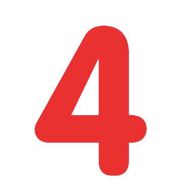

```python
#pip install pillow
# 从 PIL 库中导入 Image 模块
from PIL import Image

# 打开图像文件
img = Image.open('数字4.png')
img
```

```python
# 调整图像大小为32x32像素
img = img.resize((32,32))
img
```

```python
# 将图像转换为灰度图
img = img.convert('L')
img
```

```python
# 图片二值化处理，将灰度图转换为数字0和1
# 图片偏白色的区域赋值为0，偏黑色区域赋值为1
# 其中 0 表示黑色，255 表示白色，128 则是灰色的中间值。
img_new = img.point(lambda x: 0 if x > 128 else 1) # point()函数可以操控每一个像素点。传入的内容是一个函数，这个函数根据像素值 x 的大小返回一个新的像素值。
# lambda x: 0 if x > 128 else 1 表示使用 lambda 表达式定义了一个函数，对输入的像素值 x 进行判断：如果 x 大于 128，则返回 0，否则返回 1。这样就实现了对灰度图进行二值化处理。
img_new
```

```python
# 将图像转换为 NumPy 数组
import numpy as np
arr = np.array(img_new)
print(arr.shape[0])
print(arr.shape)
print(arr)
```

```
32
(32, 32)
[[0 0 0 ... 0 0 0]
 [0 0 0 ... 0 0 0]
 [0 0 0 ... 0 0 0]
 ...
 [0 0 0 ... 0 0 0]
 [0 0 0 ... 0 0 0]
 [0 0 0 ... 0 0 0]]
```

```python
# 打印数组的每一行
for i in range(arr.shape[0]):
    print(arr[i])
```

```
[0 0 0 0 0 0 0 0 0 0 0 0 0 0 0 0 0 0 0 0 0 0 0 0 0 0 0 0 0 0 0 0]
[0 0 0 0 0 0 0 0 0 0 0 0 0 0 0 0 0 0 0 0 0 0 0 0 0 0 0 0 0 0 0 0]
[0 0 0 0 0 0 0 0 0 0 0 0 0 0 0 0 0 0 0 0 0 0 0 0 0 0 0 0 0 0 0 0]
[0 0 0 0 0 0 0 0 0 0 0 0 0 0 0 0 0 0 0 0 0 0 0 0 0 0 0 0 0 0 0 0]
[0 0 0 0 0 0 0 0 0 0 0 0 0 0 0 0 0 0 0 0 0 0 0 0 0 0 0 0 0 0 0 0]
[0 0 0 0 0 0 0 0 0 0 0 0 0 0 0 1 1 1 1 1 0 0 0 0 0 0 0 0 0 0 0 0]
[0 0 0 0 0 0 0 0 0 0 0 0 0 0 0 1 1 1 1 1 1 0 0 0 0 0 0 0 0 0 0 0]
[0 0 0 0 0 0 0 0 0 0 0 0 0 0 1 1 1 1 1 1 1 0 0 0 0 0 0 0 0 0 0 0]
[0 0 0 0 0 0 0 0 0 0 0 0 0 1 1 1 1 1 1 1 1 1 0 0 0 0 0 0 0 0 0 0]
[0 0 0 0 0 0 0 0 0 0 0 0 0 1 1 1 1 1 1 1 1 1 0 0 0 0 0 0 0 0 0 0]
[0 0 0 0 0 0 0 0 0 0 0 0 1 1 1 1 0 1 1 1 1 1 0 0 0 0 0 0 0 0 0 0]
[0 0 0 0 0 0 0 0 0 0 0 0 1 1 1 1 0 1 1 1 1 1 0 0 0 0 0 0 0 0 0 0]
[0 0 0 0 0 0 0 0 0 0 0 1 1 1 1 0 0 1 1 1 1 1 0 0 0 0 0 0 0 0 0 0]
[0 0 0 0 0 0 0 0 0 0 0 1 1 1 1 0 0 1 1 1 1 1 0 0 0 0 0 0 0 0 0 0]
[0 0 0 0 0 0 0 0 0 0 1 1 1 1 0 0 0 1 1 1 1 1 0 0 0 0 0 0 0 0 0 0]
```

[output cut: 17 more lines]

```python
# 将数组转换为一维数组
arr_new = arr.reshape(1, -1)
print(arr_new)
print(arr_new.shape) # 32*32=1024
```

```
[[0 0 0 ... 0 0 0]]
(1, 1024)
```

```python
# 使用 KNN 分类器对图像进行预测
answer = knn.predict(arr_new)
answer
```

```
array([4], dtype=int64)
```

```python
print('图片中的数字为：' + str(answer[0]))
```

```
图片中的数字为：4
```

## 2.2 理解图像识别原理及操作，并对过程进行简短的总结

图像识别原理及操作总结：

1. 导入图像处理库 PIL 中的 Image 模块。
2. 使用 Image 模块打开名为 '数字4.png' 的图像文件，并将其赋值给变量 img。
3. 将图像大小调整为 32x32 像素，并将调整后的图像赋值给变量 img。
4. 将图像转换为灰度图像（单通道），并将转换后的图像赋值给变量 img。
5. 对灰度图像进行二值化处理，将灰度值大于 128 的像素点赋值为 0，将灰度值小于等于 128 的像素点赋值为 1，并将处理后的图像赋值给变量 img_new。
6. 将图像转换为数组，并将数组赋值给变量 arr。
7. 遍历数组 arr 的每一行，并打印每一行的元素值。
8. 将数组 arr 重新调整为一行，列数由函数自动计算得出，并将调整后的数组赋值给变量 arr_new。
9. 使用 KNN 算法对调整后的数组 arr_new 进行预测，将预测结果赋值给变量 answer。
10. 打印预测结果，即识别出的图片中的数字。

关于 `img.point(lambda x: 0 if x > 128 else 1)` 的解释：

- `img.point` 函数用于对图像的每个像素点进行操作。
- `lambda x: 0 if x > 128 else 1` 表示使用 lambda 表达式定义了一个函数，对输入的像素值 x 进行判断：如果 x 大于 128，则返回 0，否则返回 1。这样就实现了对灰度图进行二值化处理。

# 3. 分别使用带权重的KNN和指定半径的KNN对测试集进行预测，并比较其得分

## 3.1 使用带权重的KNN进行预测

```python
# 使用带权重的KNN进行预测
knn_weighted = KNN(weights='distance')  # 创建带权重的KNN分类器，使用距离作为权重
knn_weighted.fit(X_train, y_train)  # 在训练集上拟合模型
y_pred_weighted = knn_weighted.predict(X_test)  # 对测试集进行预测
y_pred_weighted
```

```
array([5, 3, 7, 8, 9, 2, 1, 4, 5, 8, 9, 5, 9, 3, 3, 2, 3, 7, 9, 1, 0, 0,
       7, 6, 6, 7, 0, 9, 6, 9, 1, 8, 6, 9, 2, 5, 2, 4, 5, 8, 3, 6, 9, 4,
       9, 2, 7, 3, 4, 9, 5, 6, 7, 3, 3, 8, 3, 1, 5, 3, 6, 7, 5, 0, 3, 7,
       1, 4, 9, 1, 5, 1, 2, 6, 9, 1, 9, 5, 5, 9, 2, 8, 8, 4, 4, 9, 4, 3,
       9, 8, 0, 3, 4, 3, 6, 8, 5, 2, 9, 0, 6, 1, 8, 9, 1, 1, 9, 4, 9, 7,
       6, 9, 2, 3, 8, 5, 5, 3, 0, 9, 1, 9, 2, 5, 4, 9, 2, 4, 9, 7, 3, 4,
       3, 6, 4, 2, 9, 7, 5, 0, 8, 2, 0, 6, 1, 4, 6, 6, 1, 4, 2, 3, 3, 6,
       2, 1, 5, 0, 3, 1, 8, 2, 5, 6, 6, 9, 2, 1, 1, 8, 6, 1, 0, 1, 7, 1,
       4, 6, 1, 0, 2, 4, 9, 4, 6, 7, 6, 9, 2, 1, 7, 5, 5, 4, 8, 6, 2, 4,
       4, 7, 1, 9, 3, 0, 3, 1, 0, 0, 8, 0, 6, 4, 0, 6, 2, 3, 6, 4, 1, 1,
       9, 7, 2, 1, 2, 8, 4, 2, 7, 9, 3, 7, 7, 0, 3, 5, 0, 8, 8, 7, 2, 6,
       8, 5, 6, 0, 5, 7, 0, 3, 4, 6, 7, 0, 3, 2, 6, 5, 8, 6, 1, 7, 0, 2,
       5, 0, 4, 7, 5, 3, 3, 6, 0, 8, 1, 0, 8, 1, 5, 9, 5, 0, 2, 8, 9, 1,
       8, 7, 4, 0, 4, 1, 5, 3, 4, 4, 6, 9, 0, 9, 1, 2, 1, 9, 0, 0, 6, 8,
       6, 0, 1, 8, 7, 5, 2, 9, 5, 9, 3, 5, 6, 1, 5, 7, 0, 4, 4, 9, 4, 9,
       8, 0, 3, 2, 5, 5, 5, 4, 2, 9, 1, 8, 2, 6, 1, 1, 1, 2, 2, 7, 1, 6,
       4, 5, 6, 0, 8, 6, 9, 8, 3, 6, 9, 8, 0, 9, 6, 8, 4, 5, 9, 8, 0, 5,
       7, 1, 3, 1, 7, 7, 9, 3, 7, 0, 9, 7, 9], dtype=int64)
```

## 3.2 使用指定半径的KNN进行预测

```python
#这行代码导入了Scikit-learn库中的RadiusNeighborsClassifier类，该类用于实现指定半径的KNN算法。通过使用这个类，我们可以指定一个半径来确定每个数据点的邻居，并进行分类预测
from sklearn.neighbors import RadiusNeighborsClassifier
X_test
```

|  | 0 | 1 | 2 | 3 | 4 | 5 | 6 | 7 | 8 | 9 | ... | 1014 | 1015 | 1016 | 1017 | 1018 | 1019 | 1020 | 1021 | 1022 | 1023 |
| --- | --- | --- | --- | --- | --- | --- | --- | --- | --- | --- | --- | --- | --- | --- | --- | --- | --- | --- | --- | --- | --- |
| 1027 | 0 | 0 | 0 | 0 | 0 | 0 | 0 | 0 | 0 | 0 | ... | 0 | 0 | 0 | 0 | 0 | 0 | 0 | 0 | 0 | 0 |
| 734 | 0 | 0 | 0 | 0 | 0 | 0 | 0 | 0 | 0 | 0 | ... | 1 | 0 | 0 | 0 | 0 | 0 | 0 | 0 | 0 | 0 |
| 1544 | 0 | 0 | 0 | 0 | 0 | 0 | 0 | 0 | 0 | 0 | ... | 0 | 0 | 0 | 0 | 0 | 0 | 0 | 0 | 0 | 0 |
| 1591 | 0 | 0 | 0 | 0 | 0 | 0 | 0 | 0 | 0 | 0 | ... | 0 | 0 | 0 | 0 | 0 | 0 | 0 | 0 | 0 | 0 |
| 1799 | 0 | 0 | 0 | 0 | 0 | 0 | 0 | 0 | 0 | 0 | ... | 0 | 0 | 0 | 0 | 0 | 0 | 0 | 0 | 0 | 0 |
| ... | ... | ... | ... | ... | ... | ... | ... | ... | ... | ... | ... | ... | ... | ... | ... | ... | ... | ... | ... | ... | ... |
| 1349 | 0 | 0 | 0 | 0 | 0 | 0 | 0 | 0 | 0 | 0 | ... | 0 | 0 | 0 | 0 | 0 | 0 | 0 | 0 | 0 | 0 |
| 134 | 0 | 0 | 0 | 0 | 0 | 0 | 0 | 0 | 0 | 0 | ... | 0 | 0 | 0 | 0 | 0 | 0 | 0 | 0 | 0 | 0 |
| 1778 | 0 | 0 | 0 | 0 | 0 | 0 | 0 | 0 | 0 | 0 | ... | 0 | 0 | 0 | 0 | 0 | 0 | 0 | 0 | 0 | 0 |
| 1360 | 0 | 0 | 0 | 0 | 0 | 0 | 0 | 0 | 0 | 0 | ... | 0 | 0 | 0 | 0 | 0 | 0 | 0 | 0 | 0 | 0 |
| 1755 | 0 | 0 | 0 | 0 | 0 | 0 | 0 | 0 | 0 | 0 | ... | 0 | 0 | 0 | 0 | 0 | 0 | 0 | 0 | 0 | 0 |

387 rows × 1024 columns

```python
# 使用指定半径的KNN进行预测
knn_radius = RadiusNeighborsClassifier(radius=13.0)  # 创建指定半径的KNN分类器对象，指定半径为13.0
knn_radius.fit(X_train, y_train)  # 使用训练集进行模型拟合
y_pred_radius = knn_radius.predict(X_test)  # 对测试集进行预测

# 输出预测结果
print('指定半径的KNN预测结果:\n', y_pred_radius)  # 打印预测结果
print('预测结果的形状:\n',y_pred_radius.shape)  # 打印预测结果的形状
```

```
指定半径的KNN预测结果:
 [5 3 7 8 9 2 1 9 5 8 9 5 9 3 3 2 3 7 9 1 0 0 7 6 6 7 0 9 6 9 1 8 6 9 2 3 2
 4 5 8 3 6 9 4 9 2 7 3 4 9 5 6 7 3 3 8 3 1 5 3 6 7 5 0 3 7 1 4 9 1 5 1 2 6
 9 1 9 5 5 9 2 8 8 4 4 9 4 3 9 8 0 3 4 3 6 8 5 2 9 0 6 1 8 9 1 1 9 4 9 7 6
 9 2 3 8 5 5 3 0 9 1 9 2 5 4 9 2 4 7 7 3 4 3 6 4 2 9 7 6 0 8 2 0 6 1 4 6 6
 1 4 2 3 3 6 2 1 5 0 3 1 1 2 5 6 6 9 2 2 1 1 6 1 0 1 7 1 4 6 1 0 2 4 8 4 6
 7 6 9 2 1 7 5 5 4 8 6 2 4 4 7 1 9 3 0 3 1 0 0 1 0 6 4 0 6 2 3 6 4 1 1 9 7
 2 1 2 8 4 2 7 1 3 7 7 0 3 5 0 8 8 7 2 6 8 5 6 0 5 7 0 3 4 6 7 0 3 2 6 5 8
 6 1 7 0 2 5 0 4 7 5 3 3 6 0 8 1 0 8 1 5 9 5 0 2 8 9 1 8 7 4 0 4 1 5 3 4 1
 6 9 0 9 1 2 1 9 0 0 6 8 6 0 1 8 7 5 2 9 5 9 3 5 6 1 5 7 0 4 4 9 4 9 8 0 3
 2 5 5 5 4 2 9 1 8 2 6 1 1 1 2 2 7 1 6 4 5 6 0 8 6 9 8 3 6 9 8 0 0 6 8 4 5
 3 8 0 5 7 1 3 3 7 7 9 3 7 0 9 7 9]
预测结果的形状:
 (387,)
```

## 3.3 比较得分

```python
from sklearn.metrics import accuracy_score
print('带权重的KNN准确率:', accuracy_score(y_test, y_pred_weighted))
print('指定半径的KNN准确率:', accuracy_score(y_test, y_pred_radius))
```

```
带权重的KNN准确率: 0.9844961240310077
指定半径的KNN准确率: 0.9534883720930233
```

带权重的KNN：

- 准确率：0.9845
- 优点：在预测过程中考虑了邻居样本的权重，更加细致地反映了邻居样本对预测结果的贡献。
- 缺点：对于密集或稀疏的数据集，可能会出现过拟合或欠拟合的情况，需要谨慎调参。

指定半径的KNN：

- 准确率：0.9535
- 优点：通过指定半径，可以控制邻居样本的数量，适用于特定的数据集和应用场景。
- 缺点：可能需要进行多次实验来确定合适的半径值，对于不同的数据集，需要谨慎选择。

综合而言，带权重的KNN在综合考虑邻居样本权重的情况下取得了更高的准确率，而指定半径的KNN则可以根据具体需求来控制邻居样本的数量，适用于特定的场景。根据实际情况和需求，可以选择合适的方法来构建模型。

# 4. 分别使用三种不同的KNN对“测试图片.png”中的数字进行预测

## 4.1 标准KNN算法预测

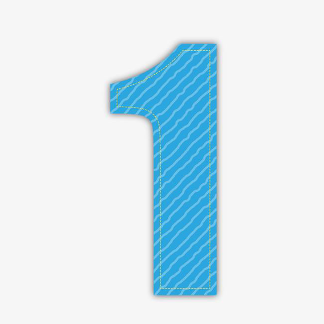

```python
img = Image.open('测试图片.png')
img
```

```python
img = img.resize((32,32))
img
```

```python
img = img.convert('L') # 将图像转换为灰度图像
                    # convert('L')函数将图像转换为灰度图像，即将图像的每个像素点的RGB值转换为对应的灰度值，范围为0-255。
img
```

```python
# 图片二值化处理，将灰度图转换为数字0和1，图片偏白色的区域赋值为0，偏黑色区域赋值为1
# point()函数可以操控每一个像素点，lambda函数用于定义一个简单的函数。
# lambda x: 0 if x > 128 else 1 表示如果像素值大于128，则赋值为0，否则赋值为1。
img_new = img.point(lambda x: 0 if x > 128 else 1)
img_new
```

```python
# 将图像转换为NumPy数组
arr = np.array(img_new)
arr
```

```
array([[0, 0, 0, ..., 0, 0, 0],
       [0, 0, 0, ..., 0, 0, 0],
       [0, 0, 0, ..., 0, 0, 0],
       ...,
       [0, 0, 0, ..., 0, 0, 0],
       [0, 0, 0, ..., 0, 0, 0],
       [0, 0, 0, ..., 0, 0, 0]], dtype=uint8)
```

```python
# 打印数组的每一行
for i in range(arr.shape[0]):
    print(arr[i])
```

```
[0 0 0 0 0 0 0 0 0 0 0 0 0 0 0 0 0 0 0 0 0 0 0 0 0 0 0 0 0 0 0 0]
[0 0 0 0 0 0 0 0 0 0 0 0 0 0 0 0 0 0 0 0 0 0 0 0 0 0 0 0 0 0 0 0]
[0 0 0 0 0 0 0 0 0 0 0 0 0 0 0 0 0 0 0 0 0 0 0 0 0 0 0 0 0 0 0 0]
[0 0 0 0 0 0 0 0 0 0 0 0 0 0 0 0 0 0 0 0 0 0 0 0 0 0 0 0 0 0 0 0]
[0 0 0 0 0 0 0 0 0 0 0 0 0 0 0 0 0 0 0 0 0 0 0 0 0 0 0 0 0 0 0 0]
[0 0 0 0 0 0 0 0 0 0 0 0 0 0 0 0 0 0 0 0 0 0 0 0 0 0 0 0 0 0 0 0]
[0 0 0 0 0 0 0 0 0 0 0 0 0 0 0 0 0 0 0 0 0 0 0 0 0 0 0 0 0 0 0 0]
[0 0 0 0 0 0 0 0 0 0 0 0 0 0 0 0 0 0 0 0 0 0 0 0 0 0 0 0 0 0 0 0]
[0 0 0 0 0 0 0 0 0 0 0 0 0 0 0 0 0 0 0 0 0 0 0 0 0 0 0 0 0 0 0 0]
[0 0 0 0 0 0 0 0 0 0 0 0 0 0 0 0 0 0 0 0 0 0 0 0 0 0 0 0 0 0 0 0]
[0 0 0 0 0 0 0 0 0 0 0 0 0 0 0 0 0 0 0 0 0 0 0 0 0 0 0 0 0 0 0 0]
[0 0 0 0 0 0 0 0 0 0 0 0 0 0 0 0 0 0 0 0 0 0 0 0 0 0 0 0 0 0 0 0]
[0 0 0 0 0 0 0 0 0 0 0 0 0 0 0 0 0 0 0 0 0 0 0 0 0 0 0 0 0 0 0 0]
[0 0 0 0 0 0 0 0 0 0 0 0 0 0 0 0 0 0 0 0 0 0 0 0 0 0 0 0 0 0 0 0]
[0 0 0 0 0 0 0 0 0 0 0 0 0 0 0 0 0 0 0 0 0 0 0 0 0 0 0 0 0 0 0 0]
```

[output cut: 17 more lines]

```python
# 将二维数组转换为一维数组
arr_new = arr.reshape(1, -1)
arr_new.shape
```

```
(1, 1024)
```

使用标准KNN模型对图像进行预测,上面已经训练好了模型knn

```python
answer1 = knn.predict(arr_new)
answer1
```

```
array([1], dtype=int64)
```

```python
# 打印预测结果
print('图片中的数字为：' + str(answer1[0]))
```

```
图片中的数字为：1
```

## 4.2 加权KNN算法预测

使用加权KNN算法对图像进行预测，上面已经训练好了模型knn_weighted

```python
answer2 = knn_weighted.predict(arr_new)
answer2
```

```
array([1], dtype=int64)
```

```python
# 打印预测结果
print('图片中的数字为：' + str(answer2[0]))
```

```
图片中的数字为：1
```

## 4.3 指定半径为15.0的KNN进行预测

上面已经训练好半径为13.0的knn_radius模型，但运行时报错，显示radius太小，所以增大radius重新建模,发现radius为20时预测错误，radius为15时预测正确

### radius=20，预测错误

```python
# 创建KNN with Radius 模型
radius_knn = RadiusNeighborsClassifier(radius=20, weights='uniform', algorithm='auto')
```

```python
# 训练KNN with Radius 模型
radius_knn.fit(X_train, y_train)
```

```
RadiusNeighborsClassifier(radius=20)
```

```python
# 对测试集进行预测
answer3 = radius_knn.predict(arr_new)
answer3
```

```
array([7], dtype=int64)
```

```python
# 打印预测结果
print('图片中的数字为：' + str(answer3[0]))
```

```
图片中的数字为：7
```

### radius=15，预测正确

```python
# 创建KNN with Radius 模型
radius_knn = RadiusNeighborsClassifier(radius=15, weights='uniform', algorithm='auto')
# 训练KNN with Radius 模型
radius_knn.fit(X_train, y_train)
# 对测试集进行预测
answer3 = radius_knn.predict(arr_new)
# 打印预测结果
print('图片中的数字为：' + str(answer3[0]))
```

```
图片中的数字为：1
```

# 5. 手写数字拍照，使用KNN进行预测，并使用kneighbors接口找出其5近邻

## 5.1 手写数字，KNN预测

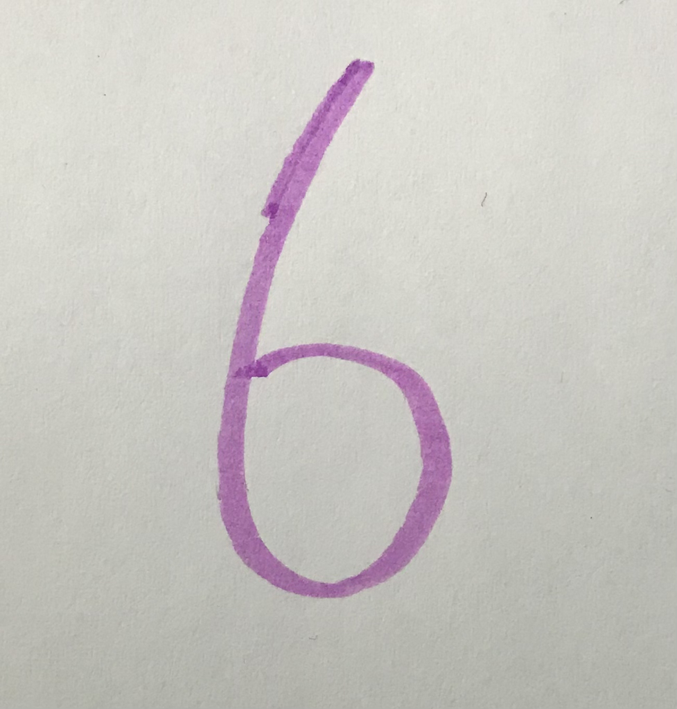

```python
img2 = Image.open('手写数字(6).png')
img2
```

```python
img2 = img2.resize((32,32))
img2
```

```python
img2 = img2.convert('L') # 将图像转换为灰度图像
                    # convert('L')函数将图像转换为灰度图像，即将图像的每个像素点的RGB值转换为对应的灰度值，范围为0-255。
img2
```

```python
# 图片二值化处理，将灰度图转换为数字0和1，图片偏白色的区域赋值为0，偏黑色区域赋值为1
# point()函数可以操控每一个像素点，lambda函数用于定义一个简单的函数。
# lambda x: 0 if x > 128 else 1 表示如果像素值大于128，则赋值为0，否则赋值为1。
img2_new = img2.point(lambda x: 0 if x > 128 else 1)
img2_new
```

```python
# 将图像转换为NumPy数组
arr2 = np.array(img2_new)
arr2
```

```
array([[0, 0, 0, ..., 0, 0, 0],
       [0, 0, 0, ..., 0, 0, 0],
       [0, 0, 0, ..., 0, 0, 0],
       ...,
       [0, 0, 0, ..., 0, 0, 0],
       [0, 0, 0, ..., 0, 0, 0],
       [0, 0, 0, ..., 0, 0, 0]], dtype=uint8)
```

```python
# 打印数组的每一行
for i in range(arr2.shape[0]):
    print(arr2[i])
```

```
[0 0 0 0 0 0 0 0 0 0 0 0 0 0 0 0 0 0 0 0 0 0 0 0 0 0 0 0 0 0 0 0]
[0 0 0 0 0 0 0 0 0 0 0 0 0 0 0 0 0 0 0 0 0 0 0 0 0 0 0 0 0 0 0 0]
[0 0 0 0 0 0 0 0 0 0 0 0 0 0 0 0 0 0 0 0 0 0 0 0 0 0 0 0 0 0 0 0]
[0 0 0 0 0 0 0 0 0 0 0 0 0 0 0 0 0 0 0 0 0 0 0 0 0 0 0 0 0 0 0 0]
[0 0 0 0 0 0 0 0 0 0 0 0 0 0 0 0 0 0 0 0 0 0 0 0 0 0 0 0 0 0 0 0]
[0 0 0 0 0 0 0 0 0 0 0 0 0 0 0 0 0 0 0 0 0 0 0 0 0 0 0 0 0 0 0 0]
[0 0 0 0 0 0 0 0 0 0 0 0 0 0 0 0 0 0 0 0 0 0 0 0 0 0 0 0 0 0 0 0]
[0 0 0 0 0 0 0 0 0 0 0 0 0 0 0 0 0 0 0 0 0 0 0 0 0 0 0 0 0 0 0 0]
[0 0 0 0 0 0 0 0 0 0 0 0 0 0 0 0 0 0 0 0 0 0 0 0 0 0 0 0 0 0 0 0]
[0 0 0 0 0 0 0 0 0 0 0 0 0 0 0 0 0 0 0 0 0 0 0 0 0 0 0 0 0 0 0 0]
[0 0 0 0 0 0 0 0 0 0 0 0 0 0 0 0 0 0 0 0 0 0 0 0 0 0 0 0 0 0 0 0]
[0 0 0 0 0 0 0 0 0 0 0 0 0 0 0 0 0 0 0 0 0 0 0 0 0 0 0 0 0 0 0 0]
[0 0 0 0 0 0 0 0 0 0 0 0 0 0 0 0 0 0 0 0 0 0 0 0 0 0 0 0 0 0 0 0]
[0 0 0 0 0 0 0 0 0 0 0 0 0 0 0 0 0 0 0 0 0 0 0 0 0 0 0 0 0 0 0 0]
[0 0 0 0 0 0 0 0 0 0 0 0 0 0 0 0 0 0 0 0 0 0 0 0 0 0 0 0 0 0 0 0]
```

[output cut: 17 more lines]

```python
# 将二维数组转换为一维数组
arr_new6 = arr.reshape(1, -1)
arr_new6.shape
```

```
(1, 1024)
```

```python
answer6 = knn_weighted.predict(arr_new6)
answer6
```

```
array([1], dtype=int64)
```

```python
# 打印预测结果
print('图片中的数字为：' + str(answer3[0]))
```

```
图片中的数字为：1
```

### 预测失败

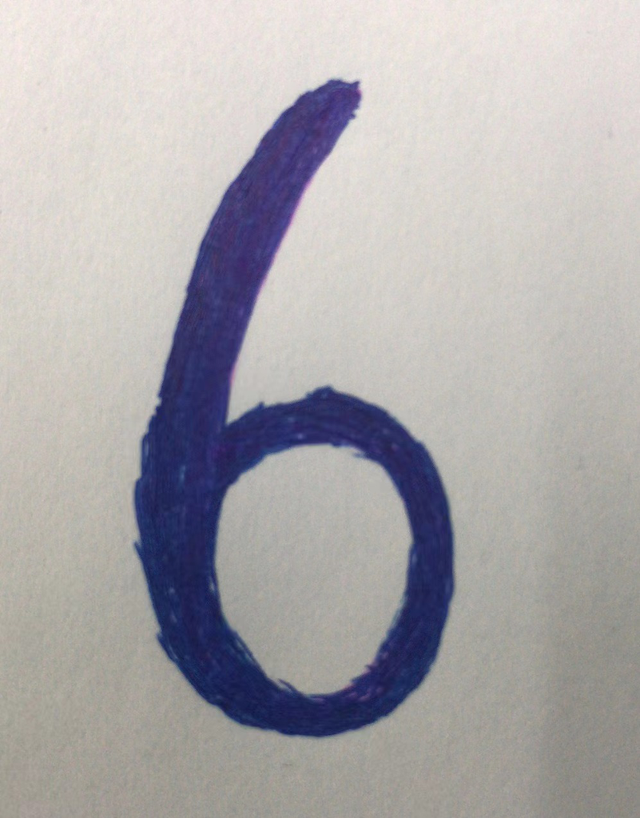

```python
img7 = Image.open('手写数字(6B).png')
img7
```

```python
img7 = img7.resize((32,32))
img7
```

```python
img7 = img7.convert('L') # 将图像转换为灰度图像
                    # convert('L')函数将图像转换为灰度图像，即将图像的每个像素点的RGB值转换为对应的灰度值，范围为0-255。
img7
```

#### 图片二值化处理，将灰度图转换为数字0和1，图片偏白色的区域赋值为0，偏黑色区域赋值为1

```python
img7_new = img7.point(lambda x: 0 if x > 128 else 1)
img7_new
```

```python
# 将图像转换为NumPy数组
arr7 = np.array(img7_new)
# 打印数组的每一行
for i in range(arr7.shape[0]):
    print(arr7[i])
```

```
[0 0 0 0 0 0 0 0 0 0 0 0 0 0 0 0 0 0 0 0 0 0 0 0 0 0 0 0 0 0 0 0]
[0 0 0 0 0 0 0 0 0 0 0 0 0 0 0 0 0 0 0 0 0 0 0 0 0 0 0 0 0 0 0 0]
[0 0 0 0 0 0 0 0 0 0 0 0 0 0 0 0 0 0 0 0 0 0 0 0 0 0 0 0 0 0 0 0]
[0 0 0 0 0 0 0 0 0 0 0 0 0 0 0 0 1 1 0 0 0 0 0 0 0 0 0 0 0 0 0 0]
[0 0 0 0 0 0 0 0 0 0 0 0 0 0 1 1 1 1 0 0 0 0 0 0 0 0 0 0 0 0 0 0]
[0 0 0 0 0 0 0 0 0 0 0 0 0 1 1 1 1 0 0 0 0 0 0 0 0 0 0 0 0 0 0 0]
[0 0 0 0 0 0 0 0 0 0 0 0 1 1 1 1 0 0 0 0 0 0 0 0 0 0 0 0 0 0 0 0]
[0 0 0 0 0 0 0 0 0 0 0 1 1 1 1 0 0 0 0 0 0 0 0 0 0 0 0 0 0 0 0 0]
[0 0 0 0 0 0 0 0 0 0 0 1 1 1 1 0 0 0 0 0 0 0 0 0 0 0 0 0 0 0 0 0]
[0 0 0 0 0 0 0 0 0 0 1 1 1 1 0 0 0 0 0 0 0 0 0 0 0 0 0 0 0 0 0 0]
[0 0 0 0 0 0 0 0 0 0 1 1 1 0 0 0 0 0 0 0 0 0 0 0 0 0 0 0 0 0 0 0]
[0 0 0 0 0 0 0 0 0 1 1 1 1 0 0 0 0 0 0 0 0 0 0 0 0 0 0 0 0 0 0 0]
[0 0 0 0 0 0 0 0 0 1 1 1 0 0 0 0 0 0 0 0 0 0 0 0 0 0 0 0 0 0 0 0]
[0 0 0 0 0 0 0 0 0 1 1 1 0 0 0 0 0 0 0 0 0 0 0 0 0 0 0 0 0 0 0 0]
[0 0 0 0 0 0 0 0 1 1 1 1 0 0 0 0 0 0 0 0 0 0 0 0 0 0 0 0 0 0 0 0]
```

[output cut: 17 more lines]

```python
# 将二维数组转换为一维数组
arr_new7 = arr7.reshape(1, -1)
arr_new7.shape
```

```
(1, 1024)
```

```python
answer7 = knn_weighted.predict(arr_new7)
answer7
```

```
array([6], dtype=int64)
```

```python
# 打印预测结果
print('图片中的数字为：' + str(answer7[0]))
```

```
图片中的数字为：6
```

## 5.2 使用kneighbors接口找出其5近邻

```python
from sklearn.neighbors import NearestNeighbors
import numpy as np
from PIL import Image

# 创建最近邻居对象并进行训练
neighbors = NearestNeighbors(n_neighbors=5, algorithm='auto').fit(X)

# 将图像转换为一维数组
arr_new7 = np.array(img7_new).reshape(1, -1)

# 使用最近邻居对象找出5个近邻
distances, indices = neighbors.kneighbors(arr_new7)

# 输出5个近邻的索引
print('5个近邻的索引:', indices)

# 输出5个近邻的图像值
print('5个近邻的图像值:', y[1187],y[1162],y[1267],y[927],y[970])
```

```
5个近邻的索引: [[1187 1162 1267  927  970]]
5个近邻的图像值: 6 6 6 4 5
```

# 5. 拆解并执行30-46行代码，掌握各种性能度量指标的使用

```python
from sklearn.metrics import accuracy_score, precision_score, recall_score, f1_score, confusion_matrix, classification_report
print('准确率:', accuracy_score(y_test, y_pred))
```

```
准确率: 0.9819121447028424
```

1. 宏平均精确率（macro-averaged precision）：计算每个类别的精确率，然后对所有类别的精确率取平均值。它对每个类别的性能给予相等的权重。
2. 微平均精确率（micro-averaged precision）：将所有类别的真阳性、假阳性和假阴性的数量累加起来，然后计算精确率。它对每个样本的性能给予相等的权重。
3. 加权平均精确率（weighted-averaged precision）：计算每个类别的精确率，然后根据类别的样本数量进行加权平均。它对每个类别的性能给予不同的权重，权重与类别的样本数量成正比。

```python
print('宏平均精确率:', precision_score(y_test,y_pred,average='macro'))
print('微平均精确率:', precision_score(y_test, y_pred, average='micro'))
print('加权平均精确率:', precision_score(y_test, y_pred, average='weighted'))
```

```
宏平均精确率: 0.983838700981558
微平均精确率: 0.9819121447028424
加权平均精确率: 0.9824216962644426
```

1. 宏平均召回率（macro-averaged recall）：计算每个类别的召回率，然后对所有类别的召回率取平均值。它对每个类别的性能给予相等的权重。
2. 微平均召回率（micro-averaged recall）：将所有类别的真阳性、假阳性和假阴性的数量累加起来，然后计算召回率。它对每个样本的性能给予相等的权重。
3. 加权平均召回率（weighted-averaged recall）：计算每个类别的召回率，然后根据类别的样本数量进行加权平均。它对每个类别的性能给予不同的权重，权重与类别的样本数量成正比。

```python
print('宏平均召回率:', recall_score(y_test,y_pred,average='macro'))
print('微平均召回率:', recall_score(y_test,y_pred,average='micro'))
print('加权平均召回率:', recall_score(y_test,y_pred,average='micro'))
```

```
宏平均召回率: 0.9820705983080004
微平均召回率: 0.9819121447028424
加权平均召回率: 0.9819121447028424
```

1. 宏平均F1-score（macro-averaged F1-score）：计算每个类别的F1-score，然后对所有类别的F1-score取平均值。它对每个类别的性能给予相等的权重。
2. 微平均F1-score（micro-averaged F1-score）：将所有类别的真阳性、假阳性和假阴性的数量累加起来，然后计算F1-score。它对每个样本的性能给予相等的权重。
3. 加权平均F1-score（weighted-averaged F1-score）：计算每个类别的F1-score，然后根据类别的样本数量进行加权平均。它对每个类别的性能给予不同的权重，权重与类别的样本数量成正比。

```python
 print('宏平均F1-score:', f1_score(y_test,y_pred,labels=[0,1,2,3,4,5,6,7,8,9],average='macro'))
print('微平均F1-score:', f1_score(y_test,y_pred,labels=[0,1,2,3,4,5,6,7,8,9],average='micro'))
print('加权平均F1-score:', f1_score(y_test,y_pred,labels=[0,1,2,3,4,5,6,7,8,9],average='weighted'))
```

```
宏平均F1-score: 0.9826788232936255
微平均F1-score: 0.9819121447028424
加权平均F1-score: 0.9818974905658197
```

1. 混淆矩阵输出（confusion matrix output）：显示了模型在每个类别上的预测结果，可以帮助你了解模型的分类准确性和误差情况。
2. 分类报告（classification report）：提供了每个类别的精确率、召回率和F1-score，以及所有类别的平均值和加权平均值。这个报告可以帮助你全面评估模型在每个类别上的性能表现。

```python
print('混淆矩阵输出:\n', confusion_matrix(y_test,y_pred,labels=[0,1,2,3,4,5,6,7,8,9]))
print('\n分类报告:\n', classification_report(y_test, y_pred,labels=[0,1,2,3,4,5,6,7,8,9]))
```

```
混淆矩阵输出:
 [[38  0  0  0  0  0  0  0  0  0]
 [ 0 43  0  0  0  0  0  0  0  1]
 [ 0  0 35  0  0  0  0  0  0  0]
 [ 0  0  0 36  0  0  0  0  0  0]
 [ 0  0  0  0 37  0  0  1  0  0]
 [ 0  0  0  0  0 38  0  0  0  1]
 [ 0  0  0  0  0  0 42  0  0  0]
 [ 0  0  0  0  0  0  0 32  0  0]
 [ 0  2  0  0  0  0  0  0 33  1]
 [ 0  0  0  0  0  1  0  0  0 46]]

分类报告:
               precision    recall  f1-score   support

           0       1.00      1.00      1.00        38
           1       0.96      0.98      0.97        44
           2       1.00      1.00      1.00        35
           3       1.00      1.00      1.00        36
           4       1.00      0.97      0.99        38
           5       0.97      0.97      0.97        39
           6       1.00      1.00      1.00        42
           7       0.97      1.00      0.98        32
           8       1.00      0.92      0.96        36
           9       0.94      0.98      0.96        47

    accuracy                           0.98       387
   macro avg       0.98      0.98      0.98       387
weighted avg       0.98      0.98      0.98       387
```

#### 根据结果的比较，对于多分类使用宏平均为最佳。

# 6. 拆解并执行49-89行代码，理解并掌握多分类如何画ROC曲线和计算AUC面积

```python
# 导入需要的模块
from sklearn.metrics import roc_curve, auc  # 导入 ROC 曲线和 AUC 相关的函数
from sklearn.preprocessing import label_binarize  # 导入标签二值化的函数
import matplotlib.pyplot as plt  # 导入 matplotlib 模块，用于绘图
```

```python
# 使用 label_binarize 函数将 y_test 进行标签二值化操作，指定了类别的列表
y_test = label_binarize(y_test, classes=[0, 1, 2, 3, 4, 5, 6, 7, 8, 9])
y_test
```

```
array([[0, 0, 0, ..., 0, 0, 0],
       [0, 0, 0, ..., 0, 0, 0],
       [0, 0, 0, ..., 1, 0, 0],
       ...,
       [0, 0, 0, ..., 0, 0, 1],
       [0, 0, 0, ..., 1, 0, 0],
       [0, 0, 0, ..., 0, 0, 1]], dtype=int32)
```

```python
# 获取二值化后的类别数量
n_classes = y_test.shape[1]
print(n_classes)
X_test
```

```
10
```

[output not shown]

```python
# 导入 numpy 模块
import numpy as np
# 确保 X_test 是一个 NumPy 数组
X_test = np.array(X_test)
```

```python
# 使用 knn 模型对 X_test 进行预测，并获取预测的概率
y_score = knn.predict_proba(X_test)
y_score
```

```
array([[0. , 0. , 0. , ..., 0. , 0. , 0. ],
       [0. , 0. , 0. , ..., 0. , 0. , 0. ],
       [0. , 0. , 0. , ..., 1. , 0. , 0. ],
       ...,
       [0. , 0. , 0. , ..., 0.2, 0. , 0.8],
       [0. , 0. , 0. , ..., 1. , 0. , 0. ],
       [0. , 0. , 0. , ..., 0. , 0. , 1. ]])
```

```python
import matplotlib.pyplot as plt  # 导入 matplotlib 模块
from itertools import cycle  # 导入 cycle 函数
from sklearn.metrics import roc_curve, auc  # 导入 ROC 曲线和 AUC 相关的函数
```

```python
# 初始化字典用于存储每个类别的 fpr、tpr 和 roc_auc
fpr = dict()
tpr = dict()
roc_auc = dict()
for i in range(n_classes):
    fpr[i], tpr[i], _ = roc_curve(y_test[:, i], y_score[:, i])
    roc_auc[i] = auc(fpr[i], tpr[i])
    print(roc_auc[i])

# 计算 micro 平均的 ROC 曲线和 AUC
fpr["micro"], tpr["micro"], _ = roc_curve(y_test.ravel(), y_score.ravel())
roc_auc["micro"] = auc(fpr["micro"], tpr["micro"])
```

```
1.0
0.9979128014842301
1.0
1.0
0.9866535967425729
0.9996684350132626
1.0
0.9985915492957746
0.9860319721430832
0.9990926157697122
```

```python
# 方法二
# 计算 macro 平均的 ROC 曲线和 AUC
all_fpr = np.unique(np.concatenate([fpr[i] for i in range(n_classes)]))
mean_tpr = np.zeros_like(all_fpr)
```

```python
# 初始化 mean_tpr 为零
mean_tpr = 0.0

# 对每个类别的 tpr 进行插值操作，并累加到 mean_tpr 中
for i in range(n_classes):
    mean_tpr += np.interp(all_fpr, fpr[i], tpr[i])
```

```python
# 计算平均 tpr
mean_tpr /= n_classes

# 将平均 fpr 存储在 fpr 字典中
fpr["macro"] = all_fpr

# 将平均 tpr 存储在 tpr 字典中
tpr["macro"] = mean_tpr

# 计算 macro 平均的 AUC
roc_auc["macro"] = auc(fpr["macro"], tpr["macro"])

# 设置线宽
lw = 9
```

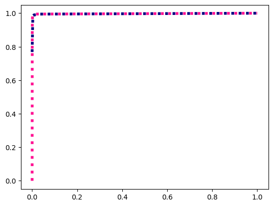

```python
# 创建一个新的图形
plt.figure()

# 绘制 micro 平均的 ROC 曲线
plt.plot(fpr["micro"], tpr["micro"], label='micro-average ROC curve (area = {0:0.2f})'.format(roc_auc["micro"]),
         color='deeppink', linestyle=':', linewidth=4)

# 绘制 macro 平均的 ROC 曲线
plt.plot(fpr["macro"], tpr["macro"], label='macro-average ROC curve (area = {0:0.2f})'.format(roc_auc["macro"]),
         color='navy', linestyle=':', linewidth=4)

# 设置颜色循环
colors = cycle(['aqua', 'darkorange', 'cornflowerblue', 'pink', 'black', 'green', 'yellow', 'brown', 'red', 'grey'])
```

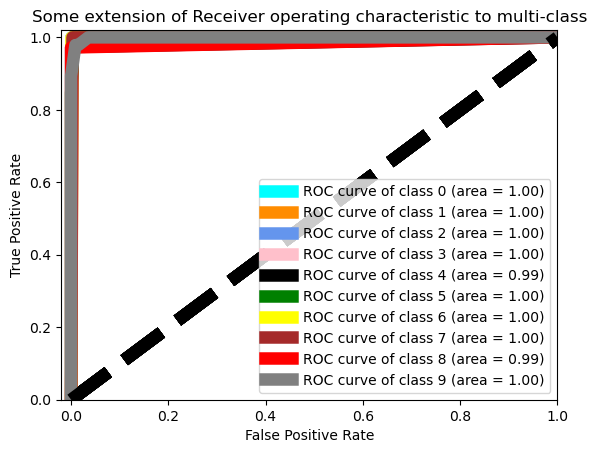

```python
# 对每个类别的 ROC 曲线进行绘制
for i, color in zip(range(n_classes), colors):
    plt.plot(fpr[i], tpr[i], color=color, lw=lw, label='ROC curve of class {0} (area = {1:0.2f})'.format(i, roc_auc[i]))
    plt.plot([0, 1], [0, 1], 'k--', lw=lw)

# 设置 x 轴范围和标签
plt.xlim([-0.02, 1.0])
plt.xlabel('False Positive Rate')

# 设置 y 轴范围和标签
plt.ylim([0.0, 1.02])
plt.ylabel('True Positive Rate')

# 设置图形标题
plt.title('Some extension of Receiver operating characteristic to multi-class')

# 添加图例并设置位置
plt.legend(loc="lower right")

# 显示图形
plt.show()
```

```python
# 对每个类别计算 ROC 曲线和 AUC
for i in range(n_classes):
    # 计算每个类别的 ROC 曲线
    fpr[i], tpr[i], _ = roc_curve(y_test[:, i], y_score[:, i])

    # 计算每个类别的 AUC
    roc_auc[i] = auc(fpr[i], tpr[i])

    # 打印每个类别的 AUC
    print(roc_auc[i])
```

```
1.0
0.9979128014842301
1.0
1.0
0.9866535967425729
0.9996684350132626
1.0
0.9985915492957746
0.9860319721430832
0.9990926157697122
```

# 7. 拆解并执行93-98行代码，理解并掌握使用网格搜索进行参数调优

GridSearch网格搜索可以进行参数调优，使用GridSearchCV()函数进行参数调优

```python
# 导入 GridSearchCV 类，用于在指定的参数网格中执行交叉验证网格搜索
from sklearn.model_selection import GridSearchCV
# 导入KNN分类器
from sklearn.neighbors import KNeighborsClassifier as KNN
import warnings
from sklearn.model_selection import train_test_split
import pandas as pd
# 忽略红色的警告
warnings.filterwarnings('ignore')
```

```python
# 定义参数网格
parameters = {'n_neighbors': [2, 3, 4, 5, 6, 7, 8, 9, 10]}
parameters
```

```
{'n_neighbors': [2, 3, 4, 5, 6, 7, 8, 9, 10]}
```

```python
# 初始化 KNN 模型
knn = KNN()  # KNN 模型在这里没有传入参数，因为参数将在网格搜索中进行调优
```

在这个实例化过程中，没有传入任何参数，因为希望在网格搜索中对 KNN 模型的参数进行调优。

KNN 模型有一个重要的参数n_neighbors，它代表了KNN算法中的“邻居”数量。这个参数的选择对于KNN算法的性能和泛化能力非常重要。为了找到最佳的n_neighbors值，我们可以使用网格搜索(GridSearchCV)来尝试不同的参数组合，并选择性能最佳的参数值。

因此，当实例化KNN模型时，不传入参数，而是留待网格搜索(GridSearchCV)来确定最佳的n_neighbors值。这样可以确保我们在模型选择过程中能够找到最优的参数组合，从而提高模型的性能和泛化能力。

```python
# 创建 GridSearchCV 对象
grid_search = GridSearchCV(knn, parameters, cv=5)
grid_search
```

```
GridSearchCV(cv=5, estimator=KNeighborsClassifier(),
             param_grid={'n_neighbors': [2, 3, 4, 5, 6, 7, 8, 9, 10]})
```

```python
# 加载数据集
df = pd.read_excel('手写体数字.xlsx')
X = df.drop('对应数字', axis=1)  # 特征
y = df['对应数字']  # 目标变量
X_train, X_test, y_train, y_test = train_test_split(X, y, test_size=0.2, random_state=123)

# 使用网格搜索训练模型
grid_search.fit(X_train, y_train)
```

```
GridSearchCV(cv=5, estimator=KNeighborsClassifier(),
             param_grid={'n_neighbors': [2, 3, 4, 5, 6, 7, 8, 9, 10]})
```

```python
# 输出最佳参数
best_n_neighbors=grid_search.best_params_['n_neighbors']
print('最佳参数n_neighbors=',best_n_neighbors)
```

```
最佳参数n_neighbors= 2
```